# Homework-4: Classification

Author

Jorge Bris Moreno

# Homework-4: Classification

**Submission:**

- Submit this assignment to Canvas as `THREE HTML (or PDF) files`, one for each section below.
- Make sure that the files are self contained and render correctly without external dependencies.

## Section-3: Python portion

### Problem 3.1

- This assignment builds off of Lab-4.1, in that lab you made a python class which acted as a “wrapper” for SkLearn. Use your solution to that lab as a starting point, but add to it in the following ways
- Generalize the class so has functionality to switch between four classifier options (Logistic regression, LDA, QDA, SVM).
- Modify the methods of the class appropriately to work with all 4 methods
- Similar to lab-4.1, run the methods of the class for all four models, on the MNIST dataset and display the results.

Note: I have also added an explanation of SVMs in the class, as it was not covered in the lab (the function explanation explains all as it could be informative to which model to pick).

```python
import numpy as np
import matplotlib.pyplot as plt
import seaborn as sns
from sklearn.linear_model import LogisticRegression
from sklearn.discriminant_analysis import LinearDiscriminantAnalysis as LDA
from sklearn.discriminant_analysis import QuadraticDiscriminantAnalysis as QDA
from sklearn.svm import SVC
from sklearn.model_selection import GridSearchCV
from sklearn.metrics import confusion_matrix, roc_curve, auc, classification_report
from sklearn.preprocessing import label_binarize
import pandas as pd
import numpy as np
from sklearn import datasets
from sklearn.model_selection import train_test_split
```

```python
# INSERT SOLUTION HERE

class Classifier:
    def __init__(self, params, model_type):

        self.model_type = model_type
        self.params = params if params is not None else {}

        # Choosing model
        if model_type == 'logistic':
            self.model = LogisticRegression(**self.params)
        elif model_type == 'lda':
            self.model = LDA(**self.params)
        elif model_type == 'qda':
            self.model = QDA(**self.params)
        elif model_type == 'svm':
            self.model = SVC(probability=True, **self.params)
        else:
            raise ValueError("That is not a valid model type! Please use logistic, lda, qda, or svm instead.")

    # fit model
    def fit(self, x_train, y_train):
      self.model.fit(x_train, y_train)
      self.classes_ = np.unique(y_train)

    # hyperparameter tuning
    def tune(self, x_train, y_train, params_try):

        # Gridsearch with cross-validation (K=4)
        self.tuner = GridSearchCV(self.model, params_try, scoring = 'accuracy', cv = 4)
        self.tuner.fit(x_train, y_train)

        # Choose best model
        self.model = self.tuner.best_estimator_

    # plot
    def plot(self, x_test, y_test):

        # plot confusion matrix
        plt.figure(figsize=(12, 8))
        preds = self.model.predict(x_test)
        cm = confusion_matrix(y_test, preds)

        sns.heatmap(cm, annot = True, fmt = 'd', cmap = plt.cm.Blues)
        plt.title('Confusion Matrix')
        plt.xlabel('Predicted Label')
        plt.ylabel('Actual Label')
        plt.show()

        # Number of classes
        num_class = len(self.classes_)

        # Prob. of class
        y_probability = self.model.predict_proba(x_test)

        # binary class.
        if num_class == 2:
            # ROC curve and ROC area for each class
            result_roc = roc_curve(y_test, y_probability[:, 1])
            false_positive_rate, true_positive_rate, _ = result_roc
            auc_roc = auc(false_positive_rate, true_positive_rate)

            # plot ROC curve
            plt.figure(figsize=(12, 8))

            # Adding random classifier line
            plt.plot([0, 1], [0, 1], color='black', lw=2, linestyle='--', label='Random classifier')

            plt.plot(false_positive_rate, true_positive_rate, color='darkred', lw=2, label=f'ROC curve (area = {auc_roc:.2f})')
            plt.title('ROC Curve')
            plt.xlabel('False Positive Rate')
            plt.ylabel('True Positive Rate')
            plt.legend(loc="lower right")
            plt.show()

        # multi-class classification
        else:
            # binary class
            y_test_binary = label_binarize(y_test, classes=self.classes_)

            true_positive_rate = dict()
            false_positive_rate = dict()
            auc_roc = dict()

            # ROC curve & area for class
            for i in range(num_class):
                true_binary_outcomes_i = y_test_binary[:, i]
                predicted_probabilities_i = y_probability[:, i]

                fpr_i, tpr_i, _ = roc_curve(true_binary_outcomes_i, predicted_probabilities_i)
                false_positive_rate[i] = fpr_i
                true_positive_rate[i] = tpr_i

                auc_roc[i] = auc(false_positive_rate[i], true_positive_rate[i])

            # plot ROC
            plt.figure(figsize=(12, 8))

            # Adding random classifier line
            plt.plot([0, 1], [0, 1], 'k--', lw=2, label='Random classifier')

            # plot ROC curve
            for i in range(num_class):
                plt.plot(false_positive_rate[i], true_positive_rate[i], lw=2,
                         label='ROC curve of number/class {0} (area ≈ {1:0.2f})'
                               ''.format(i, auc_roc[i]))

            plt.title('ROC Curves')
            plt.xlabel('False Positive Rate')
            plt.ylabel('True Positive Rate')
            plt.xlim([0.0, 1.02])
            plt.ylim([0.0, 1.02])
            plt.legend()
            plt.show()

    # report
    def report(self, x_test, y_test):

        # report
        predictions = self.model.predict(x_test)
        print(classification_report(y_test, predictions, target_names=[str(cls) for cls in self.classes_]))

    # explanation of models
    def explain(self):
        explanation = """
        Logistic Regression is a common model for classification tasks. While it stands out for binary classification problems, it can also handle multi-class
        Classification problems (with methods like One vs Rest or One vs One). The model is based on the logistic function, which is a sigmoid function that maps the input
        to a value between 0 and 1. And, in multi-class classification, the model performs this task for each class. Logistic regression is also very robust
        and can handle noise very well without overfitting. The model is also very interpretable, as it provides the probability score of the class. However,
        it assumes linearity betweeen the variables and the log-odds produced. It also assumes that the data is independent and identically distributed.

        Linear Discriminant Analysis (LDA) and Quadratic Discriminant Analysis (QDA) are also common models for classification tasks. LDA assumes that the data is normally distributed
        and that the classes have the same covariance. QDA, on the other hand, assumes that the data is normally distributed but that the classes have different covariance. Both models
        are very robust and can handle noise very well without overfitting. They are also very interpretable, as they provide the probability score of the class. However, they assume
        that the data is normally distributed and that the classes have the same covariance (LDA) or different covariance (QDA). They also assume that the data is independent and
        identically distributed. The choice on which to use depends on the data you have. While LDA is a simpler model and maybe can produce less overfitting, it
        can be too simple in some cases. QDA, on the other hand, can be more flexible and can handle more complex data. However, it can also be more prone to overfitting.

        SVMs are a very powerful model for classification tasks. They work by finding the hyperplane that separates the classes with the largest margin. They do this by maximizing the margin between the classes. The points that are closest to the hyperplane are called support vectors. The margin is the distance between the hyperplane and the support vectors. The larger the margin, the better the model. SVMs can also handle non-linear data by using kernel functions. These functions transform the data into a higher-dimensional space where the data is linearly separable. There are many types of kernel functions like linear, polynomial, and radial basis function (RBF) kernels. The choice of kernel function depends on the data you have. While the linear kernel is the simplest, it can be too simple in some cases. The polynomial kernel can handle more complex data, but it can also be more prone to overfitting. The RBF kernel is the most complex and can handle the most complex data. However, it can also be the most prone to overfitting. SVMs are particularly effective when the data is non-linear and when the classes are well separated. They are also very robust and can handle noise very well without overfitting. However, it some cases, they can be computationally expensive and can be difficult to interpret. They also require careful parameter tuning to get the best performance and extrapolation to new data.

        For Classification tasks, accruacy is a good metric to evaluate the model. It is the ratio of the correctly predicted instances to the total instances in the dataset.
        However, one flaw of accuracy is that it does not take into account the class imbalance. Precision is the ratio of correctly predicted positive observations to the total predicted positive observations.
        This provides us with the percentage of correctly predicted positive observations. Recall is the ratio of correctly predicted positive observations to the all observations in actual class.
        F1-score is the harmonic mean of Precision and Recall. It takes into account false positives and false negatives, which could be very beneficial in some cases.
        """
        print(explanation)
```

**Loading & splitting data**

```python
# load data
digits = datasets.load_digits()

# Splitting data into training and test sets
x_train, x_test, y_train, y_test = train_test_split(digits.data, digits.target, test_size=0.2, random_state=0)

print("X train shape:", x_train.shape, "X test shape:", x_test.shape)
print("y train shape:", y_train.shape, "y test shape:", y_test.shape)
```

```
X train shape: (1437, 64) X test shape: (360, 64)
y train shape: (1437,) y test shape: (360,)
```

**Explanation of models**

```python
# explaination
# (setting a model randomly to call the explanation)
params = {'C': 1.0, 'penalty': 'l2', 'solver': 'liblinear'}
classifier = Classifier(params, 'logistic')
classifier.explain()
```

[output not shown]

**Logistic Regression**

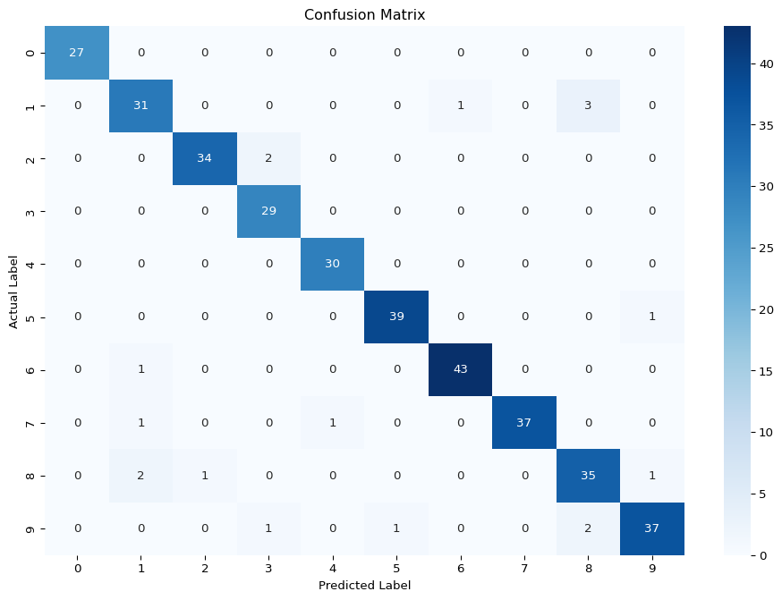

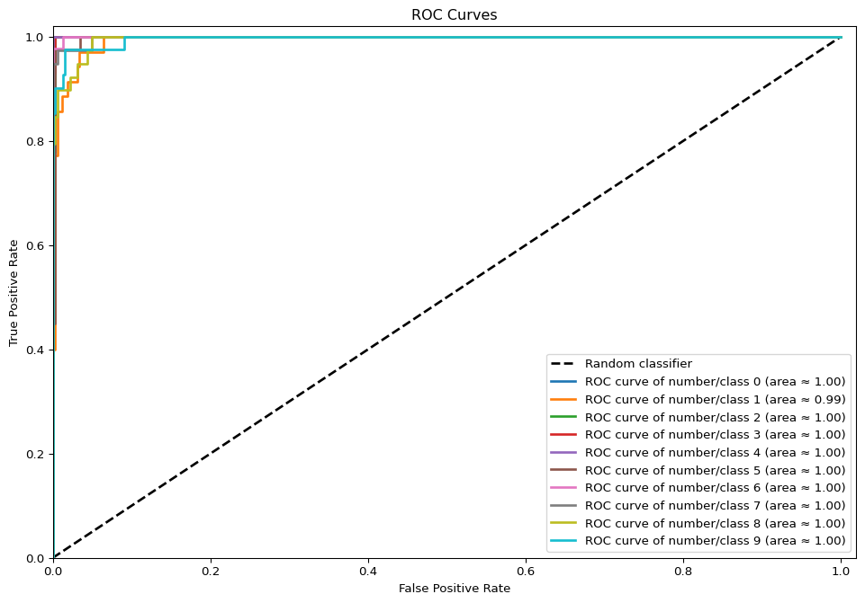

```
              precision    recall  f1-score   support

           0       1.00      1.00      1.00        27
           1       0.89      0.89      0.89        35
           2       0.97      0.94      0.96        36
           3       0.91      1.00      0.95        29
           4       0.97      1.00      0.98        30
           5       0.97      0.97      0.97        40
           6       0.98      0.98      0.98        44
           7       1.00      0.95      0.97        39
           8       0.88      0.90      0.89        39
           9       0.95      0.90      0.93        41

    accuracy                           0.95       360
   macro avg       0.95      0.95      0.95       360
weighted avg       0.95      0.95      0.95       360
```

```python
# Logistic Regression
params = {'C': 1.0, 'penalty': 'l2', 'solver': 'liblinear'}
classifier = Classifier(params, 'logistic')
classifier.fit(x_train, y_train)
classifier.plot(x_test, y_test)
classifier.report(x_test, y_test)
```

**LDA**

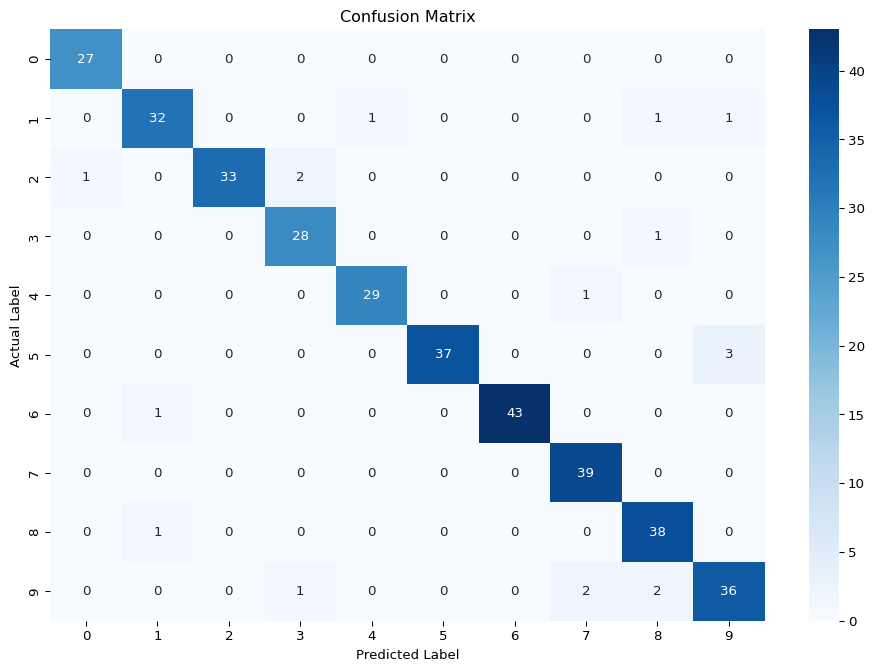

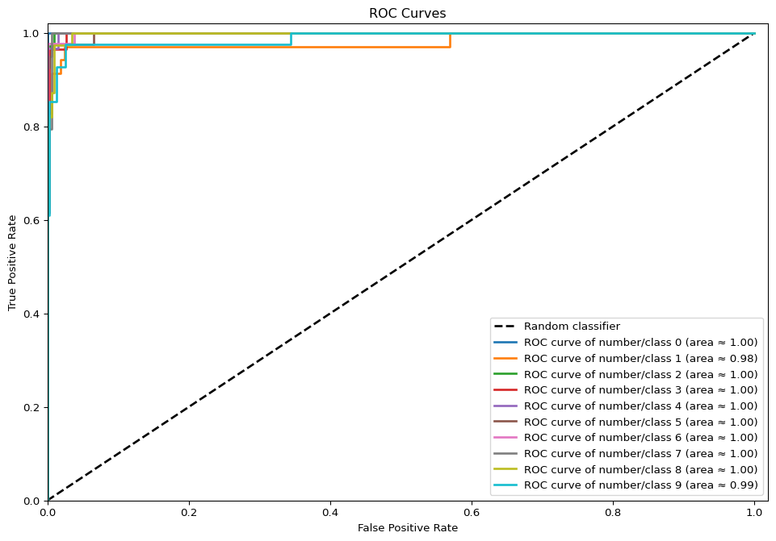

```
              precision    recall  f1-score   support

           0       0.96      1.00      0.98        27
           1       0.94      0.91      0.93        35
           2       1.00      0.92      0.96        36
           3       0.90      0.97      0.93        29
           4       0.97      0.97      0.97        30
           5       1.00      0.93      0.96        40
           6       1.00      0.98      0.99        44
           7       0.93      1.00      0.96        39
           8       0.90      0.97      0.94        39
           9       0.90      0.88      0.89        41

    accuracy                           0.95       360
   macro avg       0.95      0.95      0.95       360
weighted avg       0.95      0.95      0.95       360
```

```python
# LDA
params = {}
classifier = Classifier(params, 'lda')
classifier.fit(x_train, y_train)
classifier.plot(x_test, y_test)
classifier.report(x_test, y_test)
```

**QDA**

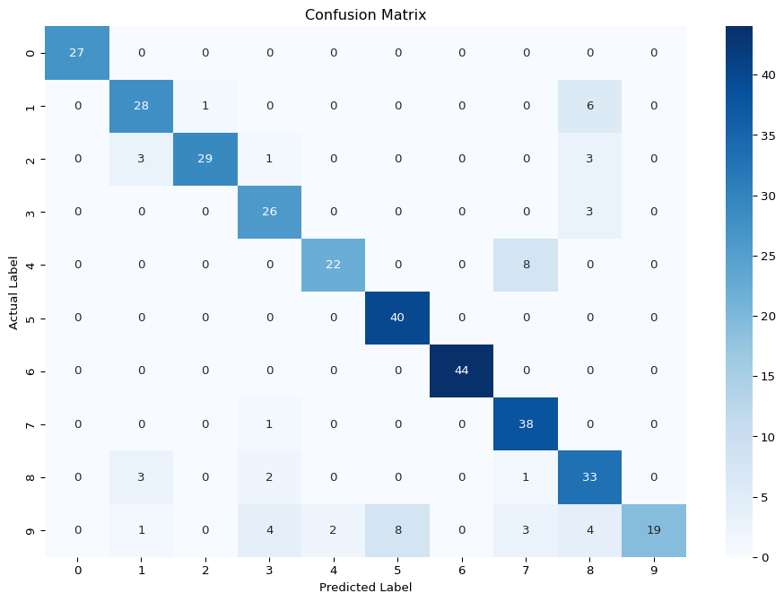

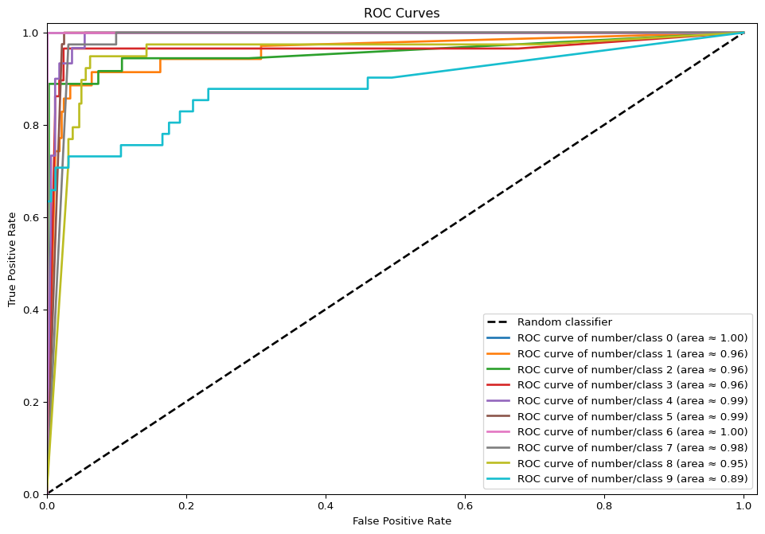

```
              precision    recall  f1-score   support

           0       1.00      1.00      1.00        27
           1       0.80      0.80      0.80        35
           2       0.97      0.81      0.88        36
           3       0.76      0.90      0.83        29
           4       0.92      0.73      0.81        30
           5       0.83      1.00      0.91        40
           6       1.00      1.00      1.00        44
           7       0.76      0.97      0.85        39
           8       0.67      0.85      0.75        39
           9       1.00      0.46      0.63        41

    accuracy                           0.85       360
   macro avg       0.87      0.85      0.85       360
weighted avg       0.87      0.85      0.84       360
```

```python
# QDA
params = {}
classifier = Classifier(params, 'qda')
classifier.fit(x_train, y_train)
classifier.plot(x_test, y_test)
classifier.report(x_test, y_test)
```

**SVM**

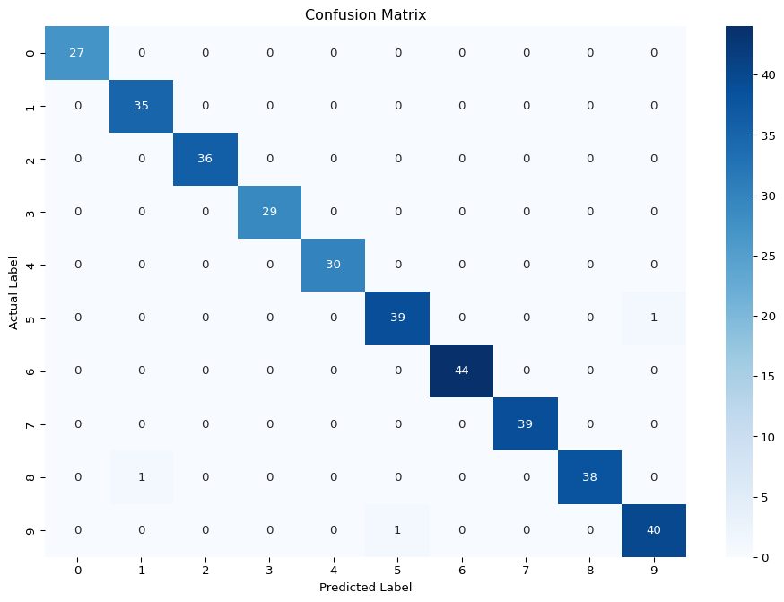

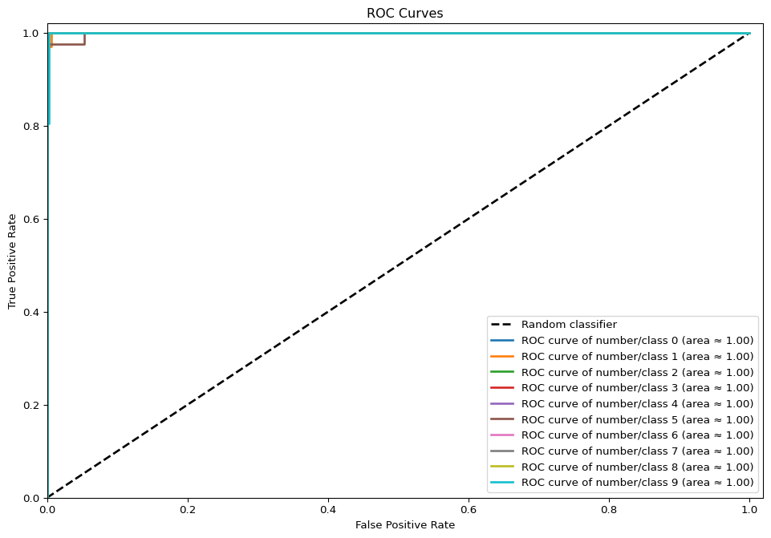

```
              precision    recall  f1-score   support

           0       1.00      1.00      1.00        27
           1       0.97      1.00      0.99        35
           2       1.00      1.00      1.00        36
           3       1.00      1.00      1.00        29
           4       1.00      1.00      1.00        30
           5       0.97      0.97      0.97        40
           6       1.00      1.00      1.00        44
           7       1.00      1.00      1.00        39
           8       1.00      0.97      0.99        39
           9       0.98      0.98      0.98        41

    accuracy                           0.99       360
   macro avg       0.99      0.99      0.99       360
weighted avg       0.99      0.99      0.99       360
```

```python
# SVM
params = {'C': 1.0, 'kernel': 'rbf', 'gamma': 'scale'}
classifier = Classifier(params, 'svm')
classifier.fit(x_train, y_train)
classifier.plot(x_test, y_test)
classifier.report(x_test, y_test)
```